# Part I - (Prosper Loans Exploration)

## by: David Akuffo-Boateng

## Introduction

> Prosper Loans is a Carlifornia-based peer-to-peer lending platform, where individuals can either invest in personal loans or request to borrow money. The dataset consisted of 113,937 loans with 81 variables.

## Preliminary Wrangling

```python
# import all packages and set plots to be embedded inline
import numpy as np
import pandas as pd
import matplotlib.pyplot as plt
import seaborn as sb

%matplotlib inline
```

> Load in your dataset and describe its properties through the questions below. Try and motivate your exploration goals through this section.

```python
loans = pd.read_csv('prosperLoanData.csv')
```

```python
loans.info
```

[output not shown]

[output cut: 64 more lines]

```python
print(loans.shape)
print(loans.dtypes)
print(loans.head(10))
```

```
(113937, 81)
ListingKey                      object
ListingNumber                    int64
ListingCreationDate             object
CreditGrade                     object
Term                             int64
                                ...
PercentFunded                  float64
Recommendations                  int64
InvestmentFromFriendsCount       int64
InvestmentFromFriendsAmount    float64
Investors                        int64
Length: 81, dtype: object
                ListingKey  ListingNumber            ListingCreationDate  \
0  1021339766868145413AB3B         193129  2007-08-26 19:09:29.263000000
```

[output cut: 71 more lines]

```python
ordinal_var_dict = {'ProsperRating (Alpha)': ['HR', 'E', 'D', 'C', 'B', 'A', 'AA'],
                    'EmploymentStatus': ['Employed', 'Self-employed', 'Full-time', 'Part-time', 'Retired', 'Other', 'Not available'],
                   'IncomeRange': ['Not employed', '$0', '$1-24,999', '$25,000-49,999',  '$50,000-74,999', '$75,000-99,999', '$100,000+'],
                   'Term': [12, 36, 60]}

for var in ordinal_var_dict:
    ordered_var = pd.api.types.CategoricalDtype(ordered = True, categories = ordinal_var_dict[var])
    loans[var] = loans[var].astype(ordered_var)
```

```python
loans.describe()
```

|  | ListingNumber | Term | BorrowerAPR | BorrowerRate | LenderYield | EstimatedEffectiveYield | EstimatedLoss | EstimatedReturn | ProsperRating (numeric) | ProsperScore | ... | LP_ServiceFees | LP_CollectionFees | LP_GrossPrincipalLoss | LP_NetPrincipalLoss | LP_NonPrincipalRecoverypayments | PercentFunded | Recommendations | InvestmentFromFriendsCount | InvestmentFromFriendsAmount | Investors |
| --- | --- | --- | --- | --- | --- | --- | --- | --- | --- | --- | --- | --- | --- | --- | --- | --- | --- | --- | --- | --- | --- |
| count | 1.139370e+05 | 113937.000000 | 113912.000000 | 113937.000000 | 113937.000000 | 84853.000000 | 84853.000000 | 84853.000000 | 84853.000000 | 84853.000000 | ... | 113937.000000 | 113937.000000 | 113937.000000 | 113937.000000 | 113937.000000 | 113937.000000 | 113937.000000 | 113937.000000 | 113937.000000 | 113937.000000 |
| mean | 6.278857e+05 | 40.830248 | 0.218828 | 0.192764 | 0.182701 | 0.168661 | 0.080306 | 0.096068 | 4.072243 | 5.950067 | ... | -54.725641 | -14.242698 | 700.446342 | 681.420499 | 25.142686 | 0.998584 | 0.048027 | 0.023460 | 16.550751 | 80.475228 |
| std | 3.280762e+05 | 10.436212 | 0.080364 | 0.074818 | 0.074516 | 0.068467 | 0.046764 | 0.030403 | 1.673227 | 2.376501 | ... | 60.675425 | 109.232758 | 2388.513831 | 2357.167068 | 275.657937 | 0.017919 | 0.332353 | 0.232412 | 294.545422 | 103.239020 |
| min | 4.000000e+00 | 12.000000 | 0.006530 | 0.000000 | -0.010000 | -0.182700 | 0.004900 | -0.182700 | 1.000000 | 1.000000 | ... | -664.870000 | -9274.750000 | -94.200000 | -954.550000 | 0.000000 | 0.700000 | 0.000000 | 0.000000 | 0.000000 | 1.000000 |
| 25% | 4.009190e+05 | 36.000000 | 0.156290 | 0.134000 | 0.124200 | 0.115670 | 0.042400 | 0.074080 | 3.000000 | 4.000000 | ... | -73.180000 | 0.000000 | 0.000000 | 0.000000 | 0.000000 | 1.000000 | 0.000000 | 0.000000 | 0.000000 | 2.000000 |
| 50% | 6.005540e+05 | 36.000000 | 0.209760 | 0.184000 | 0.173000 | 0.161500 | 0.072400 | 0.091700 | 4.000000 | 6.000000 | ... | -34.440000 | 0.000000 | 0.000000 | 0.000000 | 0.000000 | 1.000000 | 0.000000 | 0.000000 | 0.000000 | 44.000000 |
| 75% | 8.926340e+05 | 36.000000 | 0.283810 | 0.250000 | 0.240000 | 0.224300 | 0.112000 | 0.116600 | 5.000000 | 8.000000 | ... | -13.920000 | 0.000000 | 0.000000 | 0.000000 | 0.000000 | 1.000000 | 0.000000 | 0.000000 | 0.000000 | 115.000000 |
| max | 1.255725e+06 | 60.000000 | 0.512290 | 0.497500 | 0.492500 | 0.319900 | 0.366000 | 0.283700 | 7.000000 | 11.000000 | ... | 32.060000 | 0.000000 | 25000.000000 | 25000.000000 | 21117.900000 | 1.012500 | 39.000000 | 33.000000 | 25000.000000 | 1189.000000 |

8 rows × 61 columns

### What is/are the main feature(s) of interest in your dataset?

> 1. Features that increase the chances of getting a loan

### What features in the dataset do you think will help support your investigation into your feature(s) of interest?

> ProsperRating (Alpha), LoanOriginalAmount, DebtToIncomeRatio, IncomeRange, MonthlyLoanPayment, StatedMonthlyIncome, LoanOriginationDate, EmploymentStatus, IsBorrowerHomeowner, IncomeVerifiable, Term and ListingCategory.

### Which features are best in increasing the chance of getting a loan?

Let's start by looking at the distributions of the main features of interest

### ProsperRating (Alpha)

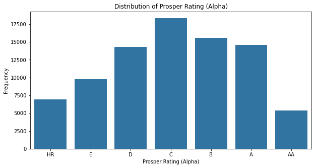

```python
plt.figure(figsize = [10,5])
base_color = sb.color_palette()[0]
sb.countplot(data = loans, x = 'ProsperRating (Alpha)', color = base_color)
plt.title('Distribution of Prosper Rating (Alpha)')
plt.xlabel('Prosper Rating (Alpha)')
plt.ylabel('Frequency')
```

The above visuals show that a greater number of people who took loans had a rating of C, and the least number of people who took loans had a rating of AA

### EmploymentStatus

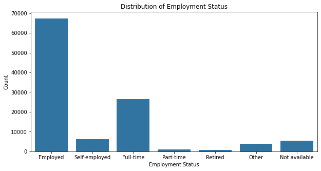

```python
plt.figure(figsize = [10,5])
sb.countplot(data = loans, x = 'EmploymentStatus', color = base_color)
plt.title('Distribution of Employment Status')
plt.xlabel('Employment Status')
plt.ylabel('Count')
```

We can see that people who borrowed are mostly employed. The least borrowers are either working part-time or retired.

### IsBorrowerHomeowner

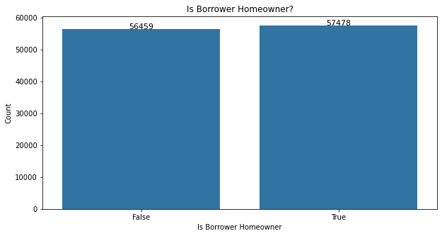

```python
plt.figure(figsize = [10,5])
ax = sb.countplot(data = loans, x = 'IsBorrowerHomeowner', color = base_color)
plt.title('Is Borrower Homeowner?')
plt.xlabel('Is Borrower Homeowner')
plt.ylabel('Count')

for p in ax.patches:
    ax.text (p.get_x() + p.get_width()  / 2, p.get_height() + 0.75, p.get_height(), horizontalalignment = 'center', fontsize = 11)
```

The number of homeowners is slightly higher than non-homeowners

### IncomeVerifiable

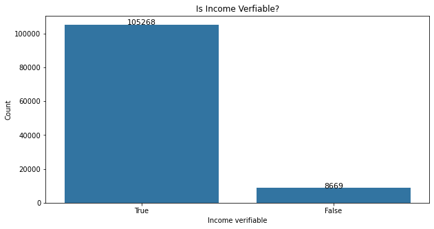

```python
veri_order = loans['IncomeVerifiable'].value_counts().index.tolist()
plt.figure(figsize = [10,5])
ax = sb.countplot(data = loans, x = 'IncomeVerifiable', color = base_color, order = veri_order)
plt.title('Is Income Verfiable?')
plt.xlabel('Income verifiable')
plt.ylabel('Count')

for p in ax.patches:
    ax.text (p.get_x() + p.get_width()  / 2, p.get_height() + 0.75, p.get_height(), horizontalalignment = 'center', fontsize = 11)
```

We can clearly see that the income of borrowers are mostly verifiable

### DebtToIncomeRatio

```
(0.0, 2.0)
```

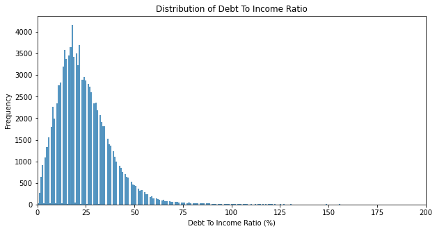

```python
plt.figure(figsize = [10,5])
sb.histplot(data = loans, x = 'DebtToIncomeRatio')
plt.title('Distribution of Debt To Income Ratio')
plt.xlabel('Debt To Income Ratio (%)')
plt.xticks([0.00, 0.25, 0.50, 0.75, 1.00, 1.25, 1.50, 1.75, 2.00], [0, 25, 50, 75, 100, 125, 150, 175, 200])
plt.ylabel('Frequency')
plt.xlim(0,2)
```

The distribution is right skewed and unimodal. Large number of borrowers have a Debt to income ratio of18%. The average ratio is 26% and we can see a continuous drop from that point.

### IncomeRange

```python
loans.IncomeRange.unique()
```

```
array(['$25,000-49,999', '$50,000-74,999', 'Not displayed', '$100,000+',
       '$75,000-99,999', '$1-24,999', 'Not employed', '$0'], dtype=object)
```

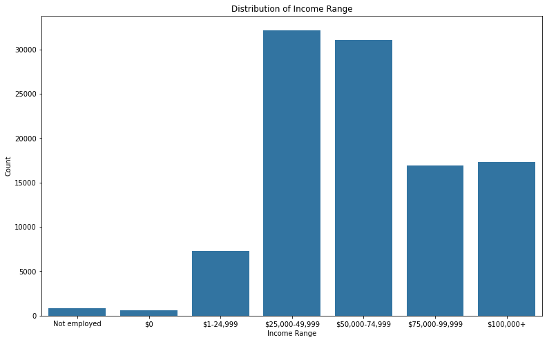

```python
# replace Not displayed with $0
loans['IncomeRange'].replace(['Not displayed'], '$0', inplace = True)

plt.figure(figsize = [13,8])
sb.countplot(data = loans, x = 'IncomeRange', color = base_color)
plt.title('Distribution of Income Range')
plt.xlabel('Income Range')
plt.ylabel('Count')
```

We can see from the graph that a large chunk of people who took loans had income range of 25000USD to 49999USD.

### LoanOriginalAmount

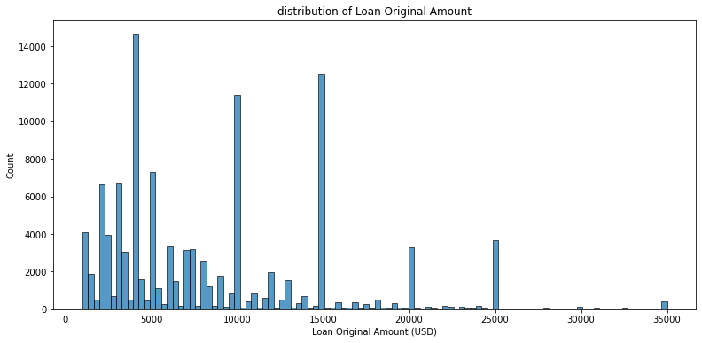

```python
plt.figure(figsize=[13, 6])
sb.histplot(data = loans, x = 'LoanOriginalAmount')
plt.title('distribution of Loan Original Amount')
plt.xlabel('Loan Original Amount (USD)')
plt.ylabel('Count')
```

### MonthlyLoanPayment

```
(0.0, 1400.0)
```

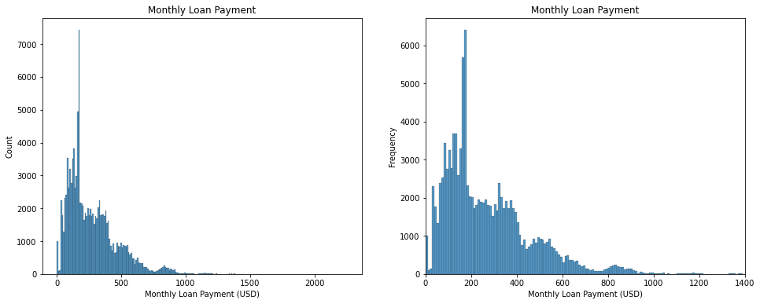

```python
plt.figure(figsize=[16, 6])

plt.subplot(1, 2, 1)
sb.histplot(data = loans, x = 'MonthlyLoanPayment')
plt.title('Monthly Loan Payment')
plt.xlabel('Monthly Loan Payment (USD)')
plt.ylabel('Count')

# there's a long tail, so let's set a limit to the x-values
plt.subplot(1, 2, 2)
bins = np.arange(0, loans['MonthlyLoanPayment'].max()+10, 10)
sb.histplot(data = loans, x = 'MonthlyLoanPayment', bins = bins)
plt.title('Monthly Loan Payment')
plt.xlabel('Monthly Loan Payment (USD)')
plt.ylabel('Frequency')
plt.xlim(0, 1400)
```

The distribution is right-skewed and unimodal, with 174 USD monthly payment having the highest number of counts. There is a high chunk of monthly loan payments up to 200 dollars. Then after 400 dollars, the number of people paying monthly loan payments decreases as the amount increases.

### StatedMonthlyIncome

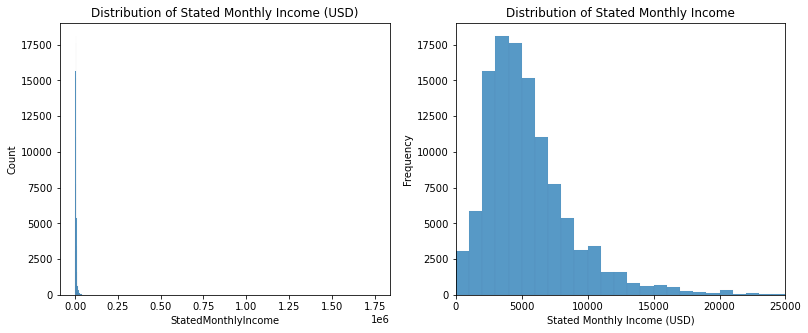

```python
plt.figure(figsize = [13,5])

plt.subplot(1, 2, 1)
bins = np.arange(0, loans['StatedMonthlyIncome'].max()+1000, 1000)
sb.histplot(data = loans, x = 'StatedMonthlyIncome', bins = bins)
plt.title('Distribution of Stated Monthly Income (USD)')

plt.subplot(1, 2, 2)
bins = np.arange(0, loans['StatedMonthlyIncome'].max()+1000, 1000)
sb.histplot(data = loans, x = 'StatedMonthlyIncome', bins = bins)
plt.xlim(0, 25000)
plt.xlabel('Stated Monthly Income (USD)')
plt.ylabel('Frequency')
plt.title('Distribution of Stated Monthly Income')
```

The distribution is right-skewed and slightly bi-modal. You could see that there're more borrowers with monthly income between 3000 dollars and 6000 dollars.

### Term

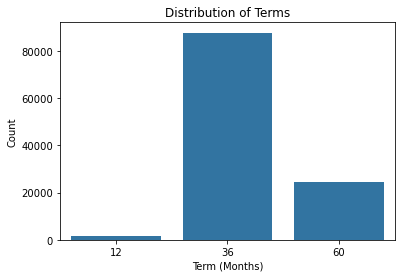

```python
sb.countplot(data = loans, x = 'Term', color = base_color)
plt.title('Distribution of Terms')
plt.xlabel('Term (Months)')
plt.ylabel('Count')
```

36 months is the term most borrowers chose to settle to repay loans, whiles 12 months is the least choice.

### ListingCategory (numeric)

```python
# create a dictionary with the nmbers corresponding to a named category
dict = {0:'Not Available', 1:'Debt Consolidation', 2:'Home Improvement', 3:'Business', 4:'Personal Loan', 5:'Student Use',
6:'Auto', 7:'Other', 8:'Baby&Adoption', 9:'Boat', 10:'Cosmetic Procedure', 11:'Engagement Ring', 12:'Green Loans',
13:'Household Expenses', 14:'Large Purchases', 15:'Medical/Dental', 16:'Motorcycle', 17:'RV', 18:'Taxes', 19:'Vacation',
20:'Wedding Loans'}

#rename column
loans = loans.rename(columns = {'ListingCategory (numeric)': 'ListingCategory'})

# map contents of the dictionary to the column
loans['ListingCategory'] = loans['ListingCategory'].map(dict)
```

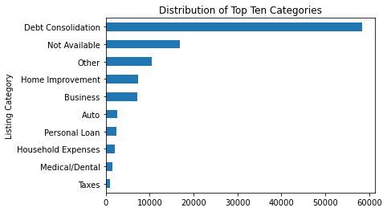

```python
# get the top ten categories and plot the distribution
top_cat = loans['ListingCategory'].value_counts()[:10]
ax = top_cat.plot.barh()
ax.invert_yaxis()
plt.ylabel('Listing Category')
plt.title('Distribution of Top Ten Categories')
```

It can be seen that the most listing category borrowers opt for is Debt consolidation when taking loans, which is quite normal in the US

### Discuss the distribution(s) of your variable(s) of interest. Were there any unusual points? Did you need to perform any transformations?

> No, there wasn't any unusual points

### Of the features you investigated, were there any unusual distributions? Did you perform any operations on the data to tidy, adjust, or change the form of the data? If so, why did you do this?

> The MonthlyLoanPayment and StatedMonthlyIncome had a long-tailed distribution with many borrowers concentrated within a range of monthly loan payments and income respectively, so we set the limit of the x axes.

> Ordered features (ProsperRating (Alpha), IncomeRange, and EmploymentStatus)into categorical data type.

> Set LoanOriginationDate to datetime data type.

> Mapped ListingCategory (numeric) to their respective descriptions for easier analysis.

## Bivariate Exploration

> In this section, investigate relationships between pairs of variables in your data. Make sure the variables that you cover here have been introduced in some fashion in the previous section (univariate exploration).

Let's look at the pairwise realtionships between variables in the data

### Features that increase the chance of getting a loan

Since management of Prosper started to introduce some variables from July 2009, it is prudent we filter our features of interest from July 1, 2009. This will do away with bias and give us more accurate insights from our features of interest.

```python
# convert LoanOriginationDate datatype to datetime
loans['LoanOriginationDate'] = pd.to_datetime(loans['LoanOriginationDate'])
```

```python
# filter loans from July 1, 2009
new_loans = loans.query('LoanOriginationDate >= "2009-07-01" ')
```

```python
# create a new categories for the new dataset
ordinal_var_dict = {'ProsperRating (Alpha)': ['HR', 'E', 'D', 'C', 'B', 'A', 'AA'],
                    'EmploymentStatus': ['Employed', 'Self-employed', 'Full-time', 'Part-time', 'Retired', 'Other', 'Not available'],
                   'IncomeRange': ['Not employed', '$0', '$1-24,999', '$25,000-49,999',  '$50,000-74,999', '$75,000-99,999', '$100,000+'],
                   'Term': [12, 36, 60]}

for var in ordinal_var_dict:
    ordered_var = pd.api.types.CategoricalDtype(ordered = True, categories = ordinal_var_dict[var])
    new_loans[var] = loans[var].astype(ordered_var)
```

Let's take a look at the correlation of our numerical values

```python
list(range(5,1))
```

```
[]
```

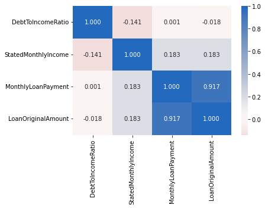

```python
num_vars = ['DebtToIncomeRatio', 'StatedMonthlyIncome', 'MonthlyLoanPayment', 'LoanOriginalAmount']

sb.heatmap(new_loans[num_vars].corr(), annot = True, fmt = '.3f', cmap = 'vlag_r', center = 0)
```

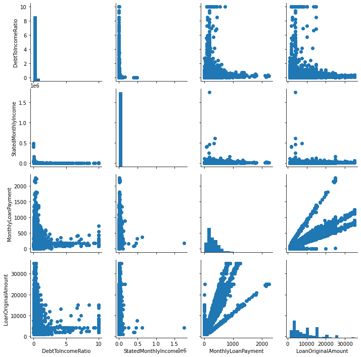

```python
#plot matrix of numerical variables
g = sb.PairGrid(data = new_loans, vars = num_vars)
g.map_diag(plt.hist, bins = 20)
g.map_offdiag(plt.scatter)
```

Let's take a look at the relationsips between other variables.

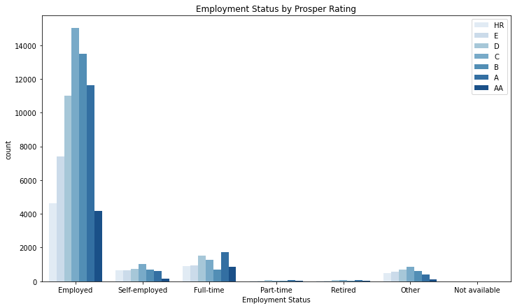

```python
# ProsperRating vs EmploymentStatus
plt.figure(figsize = [12,7])
g = sb.countplot(data = new_loans, hue = 'ProsperRating (Alpha)', x = 'EmploymentStatus', palette = 'Blues')
g.legend(loc = 1)
plt.xlabel('Employment Status')
plt.title('Employment Status by Prosper Rating')
```

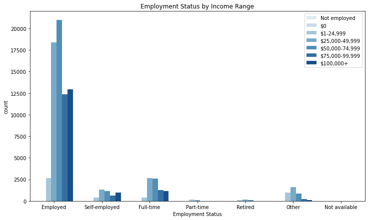

```python
# EmploymentStatus vs IncomeRange
plt.figure(figsize = [12,7])
g = sb.countplot(data = new_loans, hue = 'IncomeRange', x = 'EmploymentStatus', palette = 'Blues')
g.legend(loc = 1)
plt.xlabel('Employment Status')
plt.title('Employment Status by Income Range')
```

The graph shows that most of the borrowers who are employed had an income range of 50,000USD-74,999USD. Income range of 25,000USD-49,999USD was more prominent among Self-employed, Full-time and Other borrowers.

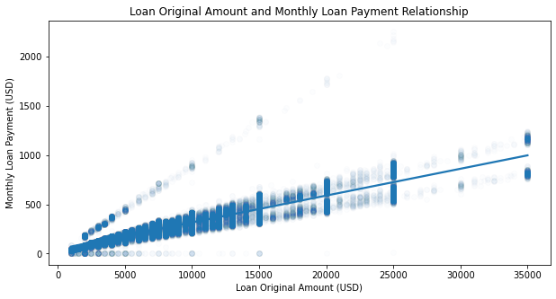

```python
#LoanOriginalAmount vs MonthlyLoanPayment
plt.figure(figsize = [10,5])
sb.regplot(data = new_loans, x = 'LoanOriginalAmount', y = 'MonthlyLoanPayment', scatter_kws = {'alpha':0.01})
plt.title('Loan Original Amount and Monthly Loan Payment Relationship')
plt.xlabel('Loan Original Amount (USD)')
plt.ylabel('Monthly Loan Payment (USD)')
```

It's clearly seen that the LoanOriginalAmount and MonthlyLoanAmount have a strong positive correlation; which obviously means that the higher the loan original amount, the higher the monthly loan payment.

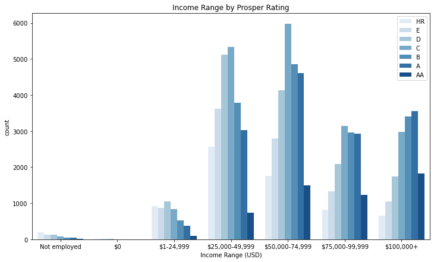

```python
# ProsperRating vs IncomeRange
plt.figure(figsize = [12,7])
g = sb.countplot(data = new_loans, hue = 'ProsperRating (Alpha)', x = 'IncomeRange', palette = 'Blues')
g.legend(loc = 1)
plt.xlabel('Income Range (USD)')
plt.title('Income Range by Prosper Rating')
```

It is seen that the higher ratings generally increases as income increases. But then again, on a hind-sight, one would think 25,000USD-49,999USD income range will have the highest number of prosper ratings, especially C-rating, since that income and C-rating had the highest number of borrowers for income range and prosper rating respectively. But the graph tells us otherwise. It shows income range of 50,000USD-74,999 having the highest number of C-ratings, which was quite interesting.

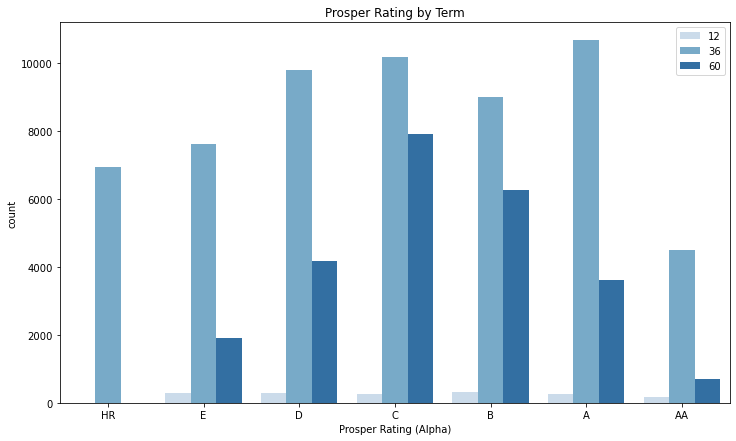

```python
# ProsperRating vs Term
plt.figure(figsize = [12,7])
g = sb.countplot(data = new_loans, x = 'ProsperRating (Alpha)', hue = 'Term', palette = 'Blues')
g.legend(loc = 1)
plt.xlabel('Prosper Rating (Alpha)')
plt.title('Prosper Rating by Term')
```

It's seen that the 36-month loan term has the highest number of people across all the ratings, with A-rating having the highest borrowers for that particular loan term. C-rating has the highest 60-month term.

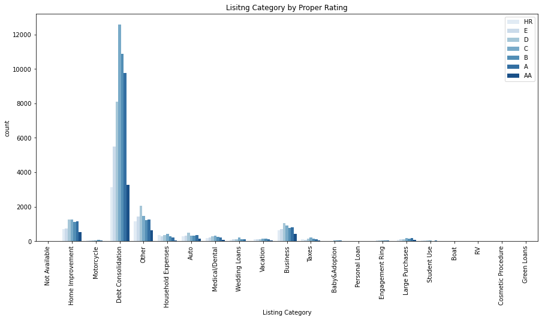

```python
top_cat = loans['ListingCategory'].value_counts()[:15]
new_loans = loans.loc[top_cat,:]

# IncomeRange vs IncomeVerifiable
plt.figure(figsize = [15,7])
g = sb.countplot(data = loans, x = 'ListingCategory', hue = 'ProsperRating (Alpha)', palette = 'Blues')
g.legend(loc = 1)
plt.xlabel('Listing Category')
plt.xticks(rotation = 90)
plt.title('Lisitng Category by Proper Rating')
```

Debt Consolidation was the most popular listing category among borrowers, and with that C-rating had the highest number of borrowers.

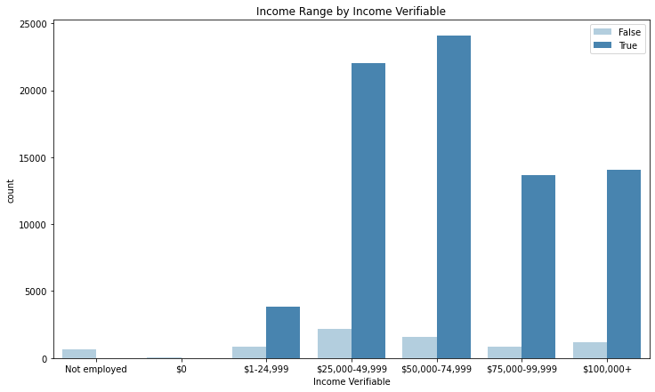

```python
# IncomeRange vs IncomeVerifiable
plt.figure(figsize = [12,7])
g = sb.countplot(data = new_loans, x = 'IncomeRange', hue = 'IncomeVerifiable', palette = 'Blues')
g.legend(loc = 1)
plt.xlabel('Income Verifiable')
plt.title('Income Range by Income Verifiable')
```

Income ranges of 25,000USD-49,999USD and 50,000USD-74,999USD clearly have more borrowers' income verified due to the high number of borrowers distribution.

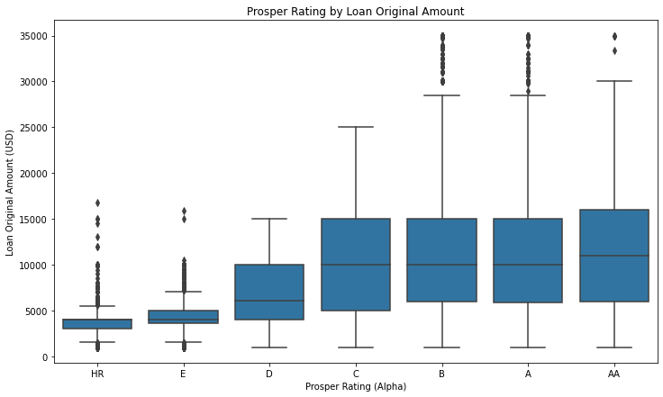

```python
# ProsperRating vs LoanOriginalAmount
plt.figure(figsize = [12,7])
sb.boxplot(data = new_loans, x = 'ProsperRating (Alpha)', y = 'LoanOriginalAmount', color = base_color)
plt.xlabel('Prosper Rating (Alpha)')
plt.ylabel('Loan Original Amount (USD)')
plt.title('Prosper Rating by Loan Original Amount')
```

It is generally seen that the higher the loan original amount the higher the prosper rating

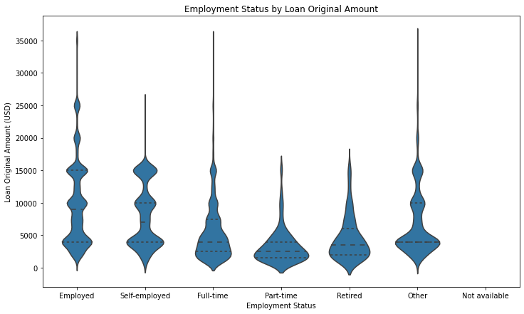

```python
# EmploymentStatus vs LoanOriginalAmount
plt.figure(figsize = [12,7])
sb.violinplot(data = new_loans, x = 'EmploymentStatus', y = 'LoanOriginalAmount', inner = 'quartile', color = base_color)
plt.xlabel('Employment Status')
plt.ylabel('Loan Original Amount (USD)')
plt.title('Employment Status by Loan Original Amount')
```

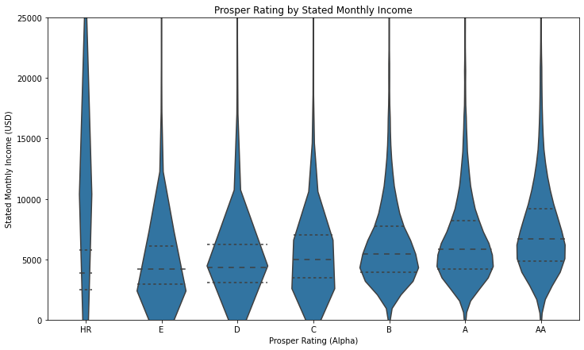

```python
# ProsperRating vs StatedMonthlyIncome
plt.figure(figsize = [12,7])
sb.violinplot(data = new_loans, x = 'ProsperRating (Alpha)', y = 'StatedMonthlyIncome', inner = 'quartile', color = base_color)
plt.xlabel('Prosper Rating (Alpha)')
plt.ylabel('Stated Monthly Income (USD)')
plt.ylim(0,25000)
plt.title('Prosper Rating by Stated Monthly Income')
```

The graph shows that borrowers with higher monthly income get a higher prosper rating.

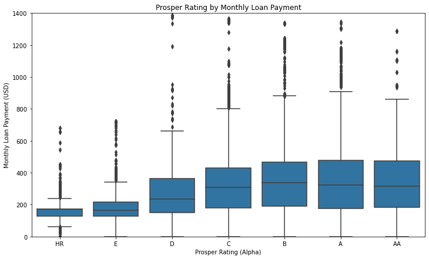

```python
# ProsperRating vs MonthlyLoanPayment
plt.figure(figsize = [12,7])
sb.boxplot(data = new_loans, x = 'ProsperRating (Alpha)', y = 'MonthlyLoanPayment', color = base_color)
plt.xlabel('Prosper Rating (Alpha)')
plt.ylabel('Monthly Loan Payment (USD)')
plt.ylim(0,1400)
plt.title('Prosper Rating by Monthly Loan Payment')
```

Generally, the higher the Monthly Loan Payment, the higher the Prosper Rating

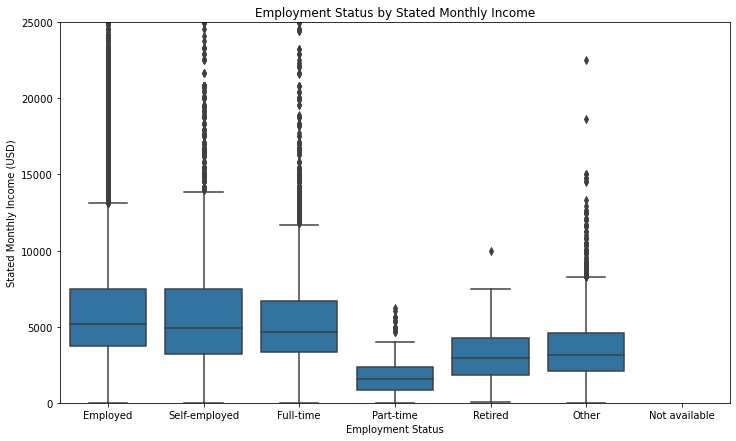

```python
# ProsperRating vs MonthlyLoanPayment
plt.figure(figsize = [12,7])
sb.boxplot(data = new_loans, x = 'EmploymentStatus', y = 'StatedMonthlyIncome', color = base_color)
plt.xlabel('Employment Status')
plt.ylabel('Stated Monthly Income (USD)')
plt.ylim(0,25000)
plt.title('Employment Status by Stated Monthly Income')
```

It can be seen that borrowers who were employed had the highest monthly incomes, followed by self-employed and then full-time borrowers. Borrowers who worked part-time had the lowest monthly incomes

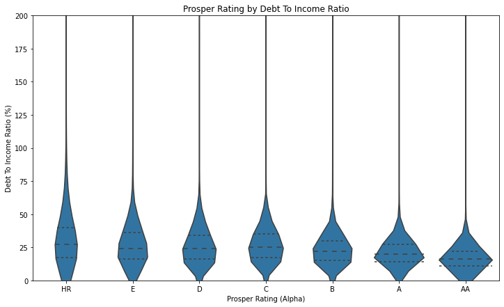

```python
# ProsperRating vs DebtToIncomeRatio
plt.figure(figsize = [12,7])
sb.violinplot(data = new_loans, x = 'ProsperRating (Alpha)', y = 'DebtToIncomeRatio', inner = 'quartile', color = base_color)
plt.xlabel('Prosper Rating (Alpha)')
plt.ylabel('Debt To Income Ratio (%)')
plt.ylim(0,2)
plt.yticks([0.00, 0.25, 0.50, 0.75, 1.00, 1.25, 1.50, 1.75, 2.00], [0, 25, 50, 75, 100, 125, 150, 175, 200])
plt.title('Prosper Rating by Debt To Income Ratio')
```

As expected, it is clearly seen that the lower your debt to income ratio, the higher your prosper rating and rate of a borrower getting a loan.

### Talk about some of the relationships you observed in this part of the investigation. How did the feature(s) of interest vary with other features in the dataset?

> Borrowers who took large amount of loans generally had a higher Propser Rating

> Borrowers with high Stated Monthly Income had a higher Prosper Rating.

> Borrowers with higher Monthly Loan Payment had higher Prosper Rating.

> Borrowers who were employed, self-employed or worked full-time had higher monthly incomes.

> Most Borrowers who took loans are employed, and most of them had higher Prosper Ratings, with C-rating having the largest number of borrowers.

> Loan Original Amount and Monthly Loan Amount had a strong positive correlation; which obviously meant that the higher the loan original amount, the higher the monthly loan payment.

> Debt Consolidation was the most popular listing category among borrowers, and with that C-rating had the highest number of borrowers.

> Debt to Income Ratio is inversely proportional to Prosper Rating; meaning the lower a borrower's debt to income ratio, the higher the prosper rating and chance of getting the loan.

> Loan Original Amount had weak positive correlation with Stated Monthly Income, according to the Pearson Correlation coefficient. This meant there was a slight chance that the higher a borrower's monthly income, the larger amount of loan that borrower requested.

### Did you observe any interesting relationships between the other features (not the main feature(s) of interest)?

> On a fore-sight, one would think 25,000USD-49,999USD income range will have the highest number of prosper ratings, especially C-rating, since that income and C-rating had the highest number of borrowers for income range and prosper rating respectively. It was observed that income range of 50,000USD-74,999 had the highest number of C-rating.

> Income range of 25,000USD-49,999USD had the highest number of borrowers who earned that amount, and also, borrowers who are employed had the highest number among the employment status. However, among the borrowers who are employed, there were more borrowers who earned an income range of 50,000USD-74,999USD.

## Multivariate Exploration

> Create plots of three or more variables to investigate your data even further. Make sure that your investigations are justified, and follow from your work in the previous sections.

Let's explore further on how features already explored played into the Prosper Rating of borrowers at the time when the listing was created, because Prosper Rating is the surefire to determine the chances of getting a loan.

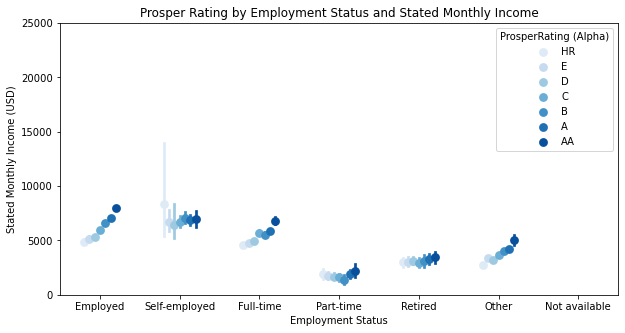

```python
plt.figure(figsize = [10,5])
sb.pointplot(data = new_loans, x = 'EmploymentStatus', y = 'StatedMonthlyIncome', hue = 'ProsperRating (Alpha)', palette = 'Blues', linestyles = '', dodge = 0.4)
plt.ylim(0, 25000)
plt.xlabel('Employment Status')
plt.ylabel('Stated Monthly Income (USD)')
plt.title('Prosper Rating by Employment Status and Stated Monthly Income')
```

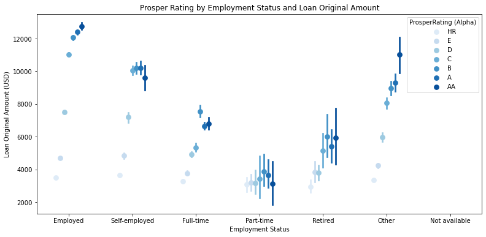

```python
plt.figure(figsize = [13,6])
sb.pointplot(data = new_loans, x = 'EmploymentStatus', y = 'LoanOriginalAmount', hue = 'ProsperRating (Alpha)', palette = 'Blues', linestyles = '', dodge = 0.4)
plt.xlabel('Employment Status')
plt.ylabel('Loan Original Amount (USD)')
plt.title('Prosper Rating by Employment Status and Loan Original Amount')
```

All borrowers who were working had higher prosper ratings and took larger amounts of loans.

[figure not shown]

```python
plt.figure(figsize = [10,5])
sb.pointplot(data = new_loans, x = 'ProsperRating (Alpha)', y = 'StatedMonthlyIncome', hue = 'Term', palette = 'Blues', linestyles = '', dodge = 0.4)
plt.ylim(0, 25000)
plt.xlabel('ProsperRating (Alpha)')
plt.ylabel('Stated Monthly Income (USD)')
plt.title('Prosper Rating by Stated Monthly Income and Term')
```

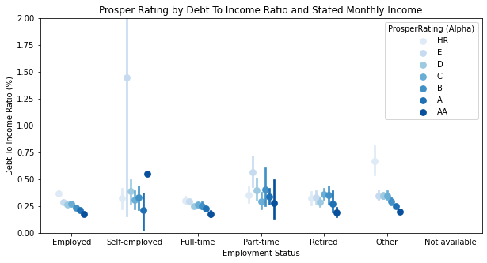

```python
plt.figure(figsize = [10,5])
sb.pointplot(data = new_loans, x = 'EmploymentStatus', y = 'DebtToIncomeRatio', hue = 'ProsperRating (Alpha)', palette = 'Blues', linestyles = '', dodge = 0.4)
plt.ylim(0, 2)
plt.xlabel('Employment Status')
plt.ylabel('Debt To Income Ratio (%)')
plt.title('Prosper Rating by Debt To Income Ratio and Stated Monthly Income')
```

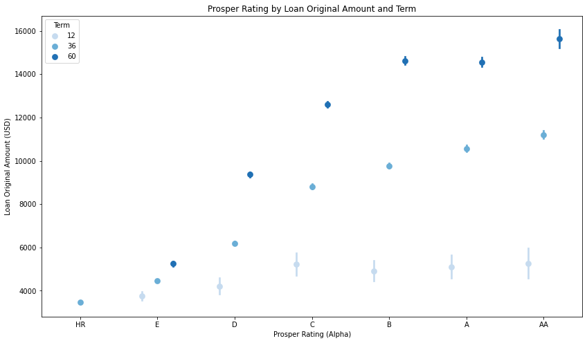

```python
# plot the relationship between Prosper Rating, Actual return and Term
plt.figure(figsize = [14, 8])
sb.pointplot(data = new_loans, x = 'ProsperRating (Alpha)', y = 'LoanOriginalAmount', hue = 'Term', palette = 'Blues', linestyles = '', dodge = 0.4)
plt.xlabel('Prosper Rating (Alpha)')
plt.ylabel('Loan Original Amount (USD)')
plt.title('Prosper Rating by Loan Original Amount and Term')
```

### Talk about some of the relationships you observed in this part of the investigation. Were there features that strengthened each other in terms of looking at your feature(s) of interest?

> All borrowers who were working had higher prosper ratings and took larger amounts of loans.

### Were there any interesting or surprising interactions between features?

> Surprisingly, the minimum monthly income for self-employed borrowers was larger than those employed.

> The highest prosper rating for self-employed borrowers had a high debt-to-income ratio.

## Conclusions

> We can clearly see factors that increased the chances of getting a loan.and these were;
> 1. Be employed
> 2. Have a low debt to income ratio
> 3. Have a loan original amount of not less than 4000USD
> 4. Have a monthly income of not less than 5000USD